# Descriptive stats for kiki/bouba experiments (field + web)

Bodo Winter

7/30/2019

This is script performs descriptive statistics of the online data and the field work experiment.

## Load in data

Load packages:

```r
library(tidyverse)
library(lsr)    # For calculating Cramer's V
library(gridExtra)

# For mapping:

library(sf)
library(ggpubr)
library(rnaturalearth)
library(rnaturalearthdata)
```

Load data:

```r
kiki <- read_csv('../data/web_experiment_cleaned.csv')
field <- read_csv('../data/field_experiment_cleaned.csv')
```

Load ggplot2 theme:

```r
source('theme_timo.R')
```

## Overall stats:

How may speakers?

```r
# Web experiment:

length(unique(kiki$ID))
```

```
## [1] 897
```

```r
# Field experiment:

length(unique(field$ID))
```

```
## [1] 131
```

How many languages?

```r
# Web experiment:

length(unique(kiki$Language))
```

```
## [1] 24
```

```r
# Field experiment:

length(unique(field$Language))
```

```
## [1] 6
```

Total number of languages across experiments?

```r
# Minus German, English, Portuguese, which are counted doubly as they occur in both:

length(unique(kiki$Language)) + length(unique(field$Language)) - 3
```

```
## [1] 27
```

How many language families?

```r
length(unique(kiki$Family))
```

```
## [1] 9
```

How many Indo-European languages?

```r
unique(filter(kiki, Family == 'IE')$Name)
```

```
##  [1] "Albanian"   "Armenian"   "Russian"    "English UK" "German"
##  [6] "Polish"     "Danish"     "Italian"    "Spanish"    "Portuguese"
## [11] "Swedish"    "Farsi"      "French"     "Greek"      "Romanian"
```

```r
length(unique(filter(kiki, Family == 'IE')$Name))
```

```
## [1] 15
```

What are the non-Indo-European language families?

```r
unique(filter(kiki, Family != 'IE')$Family)
```

```
## [1] "Sino-Tibetan" "Finno-Ugric"  "Benue-Congo"  "Tai-Kadai"
## [5] "Kartvelian"   "Japanese"     "Korean"       "Turkic"
```

```r
length(unique(filter(kiki, Family != 'IE')$Name))
```

```
## [1] 9
```

How many per language?

```r
# Web experiment:

table(filter(kiki, !duplicated(ID))$Language)
```

```
##
## AL AM CN DE DK EE EN ES FA FR GE GR HU IT JP KR PL PT RO RU SE TH TR ZU
## 10 22 48 87 18 46 41 34 22 57 14 40 35 54 55 22 52 59 33 49 21 20 38 20
```

```r
# Field experiment:

table(filter(field, !duplicated(ID))$Language)
```

```
##
## BE BR DE PA SR VA
## 56 20 20  8 15 12
```

How many languages that have non-Roman scripts?

```r
unique(kiki[kiki$Script != 'roman', ]$Name)
```

```
## [1] "Armenian" "Russian"  "Chinese"  "Thai"     "Farsi"    "Georgian"
## [7] "Greek"    "Japanese" "Korean"
```

```r
length(unique(kiki[kiki$Script != 'roman', ]$Language))
```

```
## [1] 9
```

```r
# How many of the total is that?

length(unique(kiki[kiki$Script != 'roman', ]$Language)) / length(unique(kiki$Language))
```

```
## [1] 0.375
```

9 languages out of 24, more than a third, have non-Roman scripts.

How many participants are bilingual?

```r
sum(is.na(kiki$L2))
```

```
## [1] 124
```

```r
sum(!is.na(kiki$L2)) # knows an L2
```

```
## [1] 773
```

```r
round(sum(is.na(kiki$L2)) / nrow(kiki), 2)
```

```
## [1] 0.14
```

```r
round(sum(!is.na(kiki$L2)) / nrow(kiki), 2)
```

```
## [1] 0.86
```

How many of the bilingual ones speak english as L2?

```r
kiki %>% filter(Language != 'EN') %>%
  count(EnglishL2YesNo) %>% mutate(prop = n / sum(n),
                                   prop = round(prop, 2))
```

```
## # A tibble: 2 x 3
##   EnglishL2YesNo     n  prop
##   <lgl>          <int> <dbl>
## 1 FALSE            138  0.16
## 2 TRUE             718  0.84
```

How many participants know English?

```r
kiki %>% count(EnglishL2YesNo) %>%
  mutate(Prop = n / sum(n),
         Prop = round(Prop, 2))
```

```
## # A tibble: 2 x 3
##   EnglishL2YesNo     n  Prop
##   <lgl>          <int> <dbl>
## 1 FALSE            179   0.2
## 2 TRUE             718   0.8
```

How many participants know a language with Roman alphabet as L2?

```r
kiki %>% count(RomanScriptL2) %>%
  mutate(Prop = n / sum(n),
         Prop = round(Prop, 2))
```

```
## # A tibble: 2 x 3
##   RomanScriptL2     n  Prop
##   <lgl>         <int> <dbl>
## 1 FALSE           129  0.14
## 2 TRUE            768  0.86
```

How many participants know a non-Indo-European language as L2?

```r
kiki %>% count(IEL2) %>%
  mutate(Prop = n / sum(n),
         Prop = round(Prop, 2))
```

```
## # A tibble: 2 x 3
##   IEL2      n  Prop
##   <lgl> <int> <dbl>
## 1 FALSE   126  0.14
## 2 TRUE    771  0.86
```

How many speakers are “pure non-IE speakers”, that is, they speak a non-IE language as first language and no IE as second language?

```r
kiki %>% filter(Family != 'IE') %>% count(IEL2)
```

```
## # A tibble: 2 x 2
##   IEL2      n
##   <lgl> <int>
## 1 FALSE    68
## 2 TRUE    230
```

How many speakers are “pure non-Roman script writers”, that is, they speak no language that contains the Roman script??

```r
kiki %>% filter(Script != 'roman') %>% count(RomanScriptL2)
```

```
## # A tibble: 2 x 2
##   RomanScriptL2     n
##   <lgl>         <int>
## 1 FALSE            57
## 2 TRUE            235
```

## Web experiment:

Check the overall proportion of matches:

```r
round(mean(kiki$Match, na.rm = TRUE), 2)
```

```
## [1] 0.71
```

Overall 71% matching the hypothesis (that “kiki” input = kiki shape, and “bouba” input = bouba shape).

Check this for the different L2:

```r
kiki %>%
  filter(Language != 'EN') %>%
  group_by(EnglishL2YesNo) %>%
  summarize(Match = round(mean(Match, na.rm = TRUE), 2))
```

```
## # A tibble: 2 x 2
##   EnglishL2YesNo Match
##   <lgl>          <dbl>
## 1 FALSE           0.64
## 2 TRUE            0.71
```

Check this for whether the L2 spoken has a Roman alphabet:

```r
kiki %>%
  group_by(RomanScriptL2) %>%
  summarize(Match = round(mean(Match, na.rm = TRUE), 2))
```

```
## # A tibble: 2 x 2
##   RomanScriptL2 Match
##   <lgl>         <dbl>
## 1 FALSE          0.68
## 2 TRUE           0.71
```

Check this for whether the L2 spoken is non-IE:

```r
kiki %>%
  filter(Language != 'EN') %>%
  group_by(IEL2) %>%
  summarize(Match = round(mean(Match, na.rm = TRUE), 2))
```

```
## # A tibble: 2 x 2
##   IEL2  Match
##   <lgl> <dbl>
## 1 FALSE  0.66
## 2 TRUE   0.71
```

All of these are much above chance as well.

Let’s check the “pure” speakers though:

```r
kiki %>% filter(Family != 'IE') %>% filter(!IEL2) %>%
  summarize(Match = round(mean(Match, na.rm = TRUE), 2))
```

```
## # A tibble: 1 x 1
##   Match
##   <dbl>
## 1  0.65
```

65%… still much above 50%.

How many speakers are “pure non-Roman script writers”, that is, they speak no language that contains the Roman script??

```r
kiki %>% filter(Script != 'roman') %>% filter(!RomanScriptL2) %>%
  summarize(Match = round(mean(Match, na.rm = TRUE), 2))
```

```
## # A tibble: 1 x 1
##   Match
##   <dbl>
## 1  0.67
```

Still 67%, which is much above 50%.

```r
binom.test(c(19, 38))
```

```
##
##  Exact binomial test
##
## data:  c(19, 38)
## number of successes = 19, number of trials = 57, p-value = 0.01635
## alternative hypothesis: true probability of success is not equal to 0.5
## 95 percent confidence interval:
##  0.2140053 0.4706476
## sample estimates:
## probability of success
##              0.3333333
```

This would be reliable per binomial test..

Check this for the different languages in separate mini tables:

```r
lang_tab <- kiki %>%
  group_by(Language, Name, Family, Script) %>%
  summarize(Match = mean(Match), Match = round(Match, 2))

lang_tab <- kiki %>% count(Language) %>% right_join(lang_tab)
lang_tab <- lang_tab %>%
  arrange(desc(Match))

lang_tab %>%
  print(n = Inf)
```

```
## # A tibble: 24 x 6
##    Language     n Name       Family       Script    Match
##    <chr>    <int> <chr>      <chr>        <chr>     <dbl>
##  1 SE          21 Swedish    IE           roman      1
##  2 JP          55 Japanese   Japanese     different  0.89
##  3 EN          41 English UK IE           roman      0.88
##  4 DE          87 German     IE           roman      0.83
##  5 DK          18 Danish     IE           roman      0.83
##  6 EE          46 Estonian   Finno-Ugric  roman      0.83
##  7 PL          52 Polish     IE           roman      0.83
##  8 KR          22 Korean     Korean       different  0.82
##  9 FR          57 French     IE           roman      0.81
## 10 IT          54 Italian    IE           roman      0.81
## 11 ZU          20 Zulu       Benue-Congo  roman      0.8
## 12 HU          35 Hungarian  Finno-Ugric  roman      0.77
## 13 ES          34 Spanish    IE           roman      0.71
## 14 GR          40 Greek      IE           different  0.65
## 15 TH          20 Thai       Tai-Kadai    different  0.65
## 16 GE          14 Georgian   Kartvelian   different  0.64
## 17 PT          59 Portuguese IE           roman      0.61
## 18 RU          49 Russian    IE           different  0.61
## 19 AL          10 Albanian   IE           roman      0.5
## 20 AM          22 Armenian   IE           different  0.5
## 21 FA          22 Farsi      IE           different  0.5
## 22 TR          38 Turkish    Turkic       roman      0.45
## 23 CN          48 Chinese    Sino-Tibetan different  0.38
## 24 RO          33 Romanian   IE           roman      0.36
```

Get the average proportions by script:

```r
kiki %>% group_by(Script) %>%
  summarize(Match = mean(Match))
```

```
## # A tibble: 2 x 2
##   Script    Match
##   <chr>     <dbl>
## 1 different 0.634
## 2 roman     0.747
```

Make a plot of this:

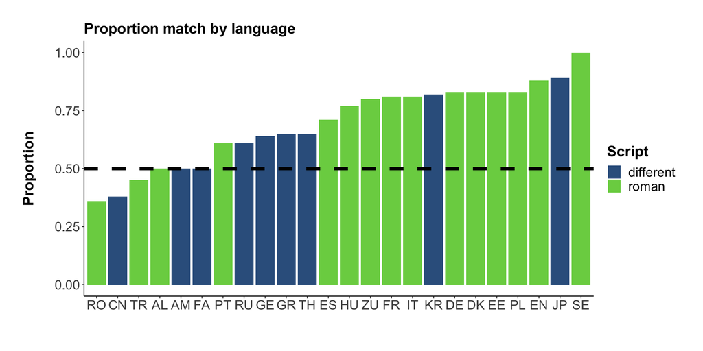

```r
lang_tab %>%
  ggplot(aes(x = reorder(Language, Match),
             y = Match, fill = Script)) +
  geom_col() +
  labs(x = '', y = 'Proportion\n') +
  ggtitle('Proportion match by language') +
  coord_cartesian(ylim = c(0, 1)) +
  geom_hline(yintercept = 0.5, linetype = 2, size = 2) +
  scale_fill_viridis_d(option = 'D', begin = 0.3, end = 0.8) +
  theme_timo
```

This suggests that languages with different scripts on average seem to have less strong of a kiki/bouba effect. Of course, that’s partially confounded with genealogical associations since languages with different scripts are more likely non-Indo-European.

Create a variable for IE versus non-IE:

```r
lang_tab <- mutate(lang_tab,
                   `Language Family` = ifelse(Family == 'IE', 'IE', 'other'))
```

Change the script label so it’s nice for plotting:

```r
lang_tab <- mutate(lang_tab,
                   Script = ifelse(Script == 'roman', 'Roman script', 'non-Roman script'))
```

Make a plot broken up by IE versus non-IE:

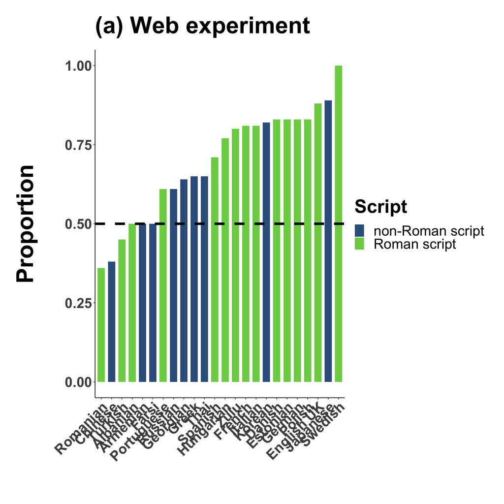

```r
# Aesthetics:

web_p <- lang_tab %>%
  ggplot(aes(x = reorder(Name, Match),
             y = Match, fill = Script))

# Geoms:

web_p <- web_p +
  geom_bar(stat = 'identity', width = 0.7) +
  geom_hline(yintercept = 0.5, linetype = 2, size = 2)

# Extra stuff:

web_p <- web_p +
  labs(x = '', y = 'Proportion\n') +
  ggtitle('(a) Web experiment') +
  coord_cartesian(ylim = c(0, 1)) +
  scale_fill_viridis_d(option = 'D', begin = 0.3, end = 0.8, direction = 1) +
  theme_timo +
  theme(axis.text.x = element_text(angle = 45, hjust = 1, face = 'bold', size = 24),
        axis.text.y = element_text(face = 'bold', size = 24),
        axis.title = element_text(face = 'bold', size = 40),
        axis.title.y = element_text(face = 'bold', size = 40),
        plot.title = element_text(face = 'bold', size = 40,
                                  margin = margin(t = 0, r = 0,
                                                  b = 20, l = 0)),
        legend.text = element_text(size = 24),
        legend.title = element_text(size = 32, face = 'bold'))

# Show:

web_p
```

## Field experiment:

For the field experiment, we had the planning issue that in all cases except Daakie, the written experiment was run first. This makes this data not open to testing the idea that there is a genuine effect of spoken iconicity, as the spoken responses are contaminated because of having seen the spiky and round letters first.

Because of this, we are only going to look at Daakie for the analysis reported in the paper.

It should be noted that the results from the other languages do support the kiki/bouba effect, but only the ritten version

Let’s get only the Daakie data points:

```r
field_red <- filter(field, Language == 'VA', Modality == 'Aud')
```

First, overall match:

```r
str_c(round(mean(field_red$Match), 3) * 100, '%')
```

```
## [1] "83.3%"
```

This is such little data, let’s make a table:

```r
table(field_red$Match)
```

```
##
##  0  1
##  2 10
```

Write this to table for Bayesian analysis:

```r
write_csv(field_red, '../data/field_daakie_only.csv')
```

## Analysis of the remaining data (not reported in paper):

First, overall match:

```r
mean(field$Match, na.rm = TRUE)
```

```
## [1] 0.897541
```

Check result depending on whether modality was auditory or written (aggregating across languages and speakers):

```r
field %>% group_by(Modality) %>%
  summarize(Match = mean(Match, na.rm = TRUE))
```

```
## # A tibble: 2 x 2
##   Modality Match
##   <chr>    <dbl>
## 1 Aud      0.901
## 2 Ort      0.894
```

```r
field <- filter(field, Modality == 'Aud')
```

Check results by languages:

```r
field_lang_tab <- field %>%
  group_by(Language) %>%
  summarize(Match = mean(Match, na.rm = TRUE),
            Match = round(Match, 2))

field_lang_tab <- field %>% count(Language) %>% right_join(field_lang_tab)
field_lang_tab <- field_lang_tab %>%
  arrange(desc(Match))

field_lang_tab
```

```
## # A tibble: 6 x 3
##   Language     n Match
##   <chr>    <int> <dbl>
## 1 DE          20  1
## 2 BE          56  0.95
## 3 BR          20  0.9
## 4 VA          12  0.83
## 5 PA           8  0.75
## 6 SR          15  0.73
```

For plot, create full language names:

```r
field_lang_tab$Name <- c('British English',
                         'Tashlhiyt Berber',
                         'German',
                         'Daakie',
                         'Palikur',
                         'Brazilian Portuguese')
```

Make a plot of this:

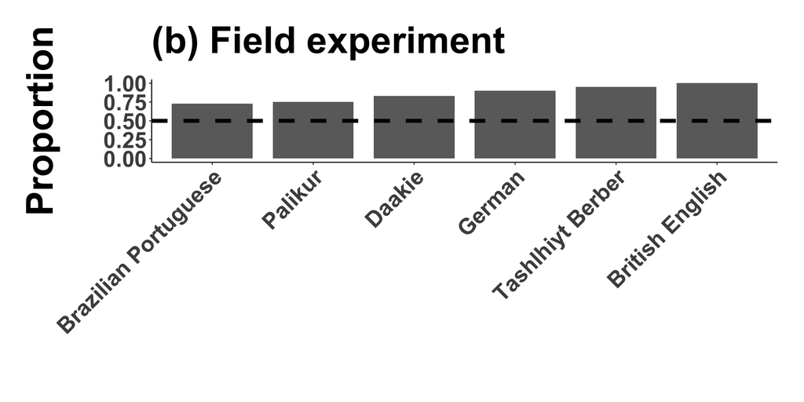

```r
# Aesthetics:

field_p <- field_lang_tab %>%
  ggplot(aes(x = reorder(Name, Match),
             y = Match))

# Geoms:

field_p <- field_p +
  geom_bar(fill = 'gray42', stat = 'identity', width = 0.8)

# Extra stuff:

field_p <- field_p +
  labs(x = '', y = 'Proportion\n') +
  ggtitle('(b) Field experiment') +
  coord_cartesian(ylim = c(0, 1)) +
  geom_hline(yintercept = 0.5, linetype = 2, size = 2) +
  theme_timo +
  theme(axis.text.x = element_text(angle = 45, hjust = 1, face = 'bold', size = 24),
        axis.text.y = element_text(face = 'bold', size = 24),
        axis.title = element_text(face = 'bold', size = 40),
        axis.title.y = element_text(face = 'bold', size = 40),
        legend.position = 'none',
        plot.title = element_text(face = 'bold', size = 40,
                                  margin = margin(t = 0, r = 0,
                                                  b = 20, l = 0)))

# Plot:

field_p
```

## Combine both plots:

First, create a layout matrix:

```r
my_layout <- rbind(c(1, 1, 1, 1, 1, 1, 1, 1, 1, 1, 1),
                   c(1, 1, 1, 1, 1, 1, 1, 1, 1, 1, 1),
                   c(1, 1, 1, 1, 1, 1, 1, 1, 1, 1, 1),
                   c(1, 1, 1, 1, 1, 1, 1, 1, 1, 1, 1),
                   c(1, 1, 1, 1, 1, 1, 1, 1, 1, 1, 1),
                   c(1, 1, 1, 1, 1, 1, 1, 1, 1, 1, 1),
                   c(1, 1, 1, 1, 1, 1, 1, 1, 1, 1, 1),
                   c(NA, NA, NA, NA, NA, NA, NA, NA, NA, NA, NA),
                   c(2, 2, 2, 2, 2, 2, NA, NA, NA, NA, NA),
                   c(2, 2, 2, 2, 2, 2, NA, NA, NA, NA, NA),
                   c(2, 2, 2, 2, 2, 2, NA, NA, NA, NA, NA),
                   c(2, 2, 2, 2, 2, 2, NA, NA, NA, NA, NA),
                   c(2, 2, 2, 2, 2, 2, NA, NA, NA, NA, NA),
                   c(2, 2, 2, 2, 2, 2, NA, NA, NA, NA, NA))
```

Then, create the double plot:

[figure not shown]

```r
multi_plot <- grid.arrange(web_p, field_p,
                           layout_matrix = my_layout)
```

```r
ggsave(plot = multi_plot, '../figures/per_language_barplots.png', width = 24, height = 20)
ggsave(plot = multi_plot, '../figures/per_language_barplots.pdf', width = 24, height = 20)
```

This completes this analysis.

## Plot of the world map:

Load country-level data:

```r
web_countries <- read_csv('../data/countries_map_online.csv')

# From: https://developers.google.com/public-data/docs/canonical/countries_csv

canonical <- read_csv('../data/countries.csv')
```

Merge the longitude and latitude info in there:

```r
web_countries <- left_join(web_countries, canonical,
                           by = c('CountryCode' = 'country'))
```

Make a map:

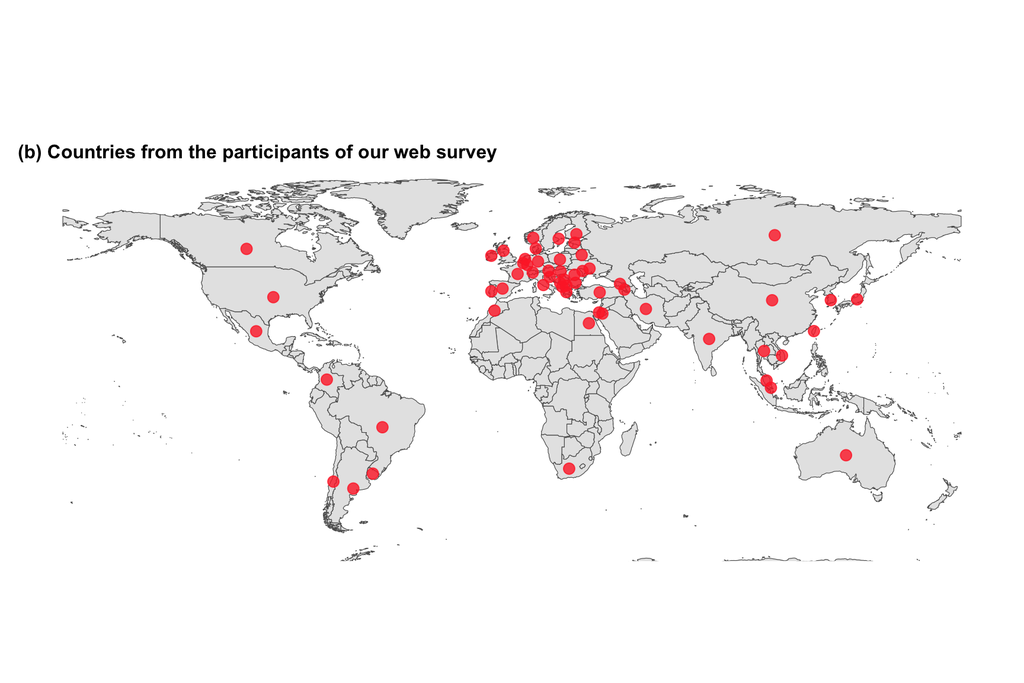

```r
world <- ne_countries(scale = "medium", returnclass = "sf")

world_p <- ggplot(world) +
  geom_sf(size=0.2) +
  coord_sf(xlim = c(-180, 180), ylim = c(-60, 80), datum=NA) +
  geom_point(data = web_countries,
             aes(x = longitude, y = latitude, group = NA),
             alpha = 0.8, position = position_jitter(0.1), size = 3,
             col = 'firebrick1') +
  labs(title = "(b) Countries from the participants of our web survey") +
  theme_timo +
  theme(
    axis.title = element_blank(),
    axis.text = element_blank(),
    axis.line = element_blank(),
    axis.ticks = element_blank(),
    plot.margin = unit(c(0.1,0.4,-0.4,0.4),"cm"),
    panel.spacing = unit(0, "lines"),
    plot.title = element_text(size = 12))

# Plot:

world_p
```

```r
# Save:

ggsave('../figures/Figure2_world_map.pdf', plot = world_p)
```